# Изучение закономерностей, определяющих успешность игр

### Сравнение результатов и выводов по платформам

```python
ps3 = df_actual.query('platform =="PS3"')
wii = df_actual.query('platform =="Wii"')
ps4 = df_actual.query('platform =="PS4"')
## pc = df_actual.query('platform =="PC"') Выпал из рейтинга заменяю на 3DS
ds3 = df_actual.query('platform =="3DS"')
```

```python
ps3_ab = df_alternative.query('platform =="PS3"')
ps4_ab = df_alternative.query('platform =="PS4"')
xone_ab = df_alternative.query('platform =="XOne"')
## ds3_ab = df_alternative.query('platform =="3DS"') не нужна, так как платформа вышла в 2011 году и вся поместилась в df_actual
```

#### Влияние отзывов критиков на продажи

##### PS3

```
Корелляция: 0.4336947594503307
```

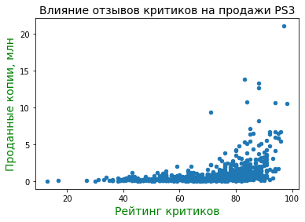

```python
print('Корелляция:', ps3['critic_score'].corr(ps3['all_sales']))

ps3.plot(x='critic_score', y='all_sales', kind='scatter')
plt.title('Влияние отзывов критиков на продажи PS3', fontsize = 14)
plt.xlabel('Рейтинг критиков', color = 'green', fontsize = 14)
plt.ylabel('Проданные копии, млн', color = 'green', fontsize = 14);
```

###### АВ 🎈

```
Корелляция: 0.4336947594503307
```

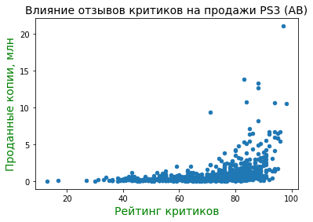

```python
print('Корелляция:', ps3['critic_score'].corr(ps3['all_sales']))

ps3.plot(x='critic_score', y='all_sales', kind='scatter')
plt.title('Влияние отзывов критиков на продажи PS3 (АВ)', fontsize = 14)
plt.xlabel('Рейтинг критиков', color = 'green', fontsize = 14)
plt.ylabel('Проданные копии, млн', color = 'green', fontsize = 14);
```

##### Wii

```
Корелляция: 0.1775598880608996
```

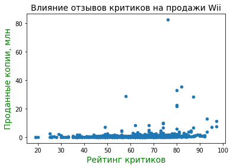

```python
print('Корелляция:', wii['critic_score'].corr(wii['all_sales']))

wii.plot(x='critic_score', y='all_sales', kind='scatter')
plt.title('Влияние отзывов критиков на продажи Wii', fontsize = 14)
plt.xlabel('Рейтинг критиков', color = 'green', fontsize = 14)
plt.ylabel('Проданные копии, млн', color = 'green', fontsize = 14);

#альтернативной выборки нет, так как Wii не вошла в топ 5
```

##### PS4

```
Корелляция: 0.40656790206178095
```

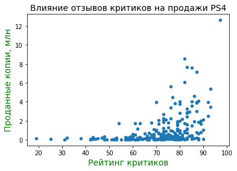

```python
print('Корелляция:', ps4['critic_score'].corr(ps4['all_sales']))

ps4.plot(x='critic_score', y='all_sales', kind='scatter')
plt.title('Влияние отзывов критиков на продажи PS4', fontsize = 14)
plt.xlabel('Рейтинг критиков', color = 'green', fontsize = 14)
plt.ylabel('Проданные копии, млн', color = 'green', fontsize = 14);
```

###### АВ 🎈

```
Корелляция: 0.40656790206178095
```

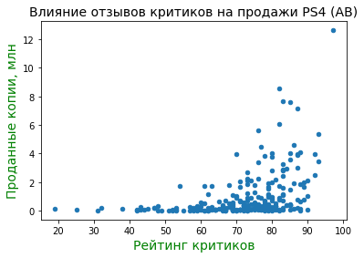

```python
print('Корелляция:', ps4_ab['critic_score'].corr(ps4_ab['all_sales']))

ps4_ab.plot(x='critic_score', y='all_sales', kind='scatter')
plt.title('Влияние отзывов критиков на продажи PS4 (АВ)', fontsize = 14)
plt.xlabel('Рейтинг критиков', color = 'green', fontsize = 14)
plt.ylabel('Проданные копии, млн', color = 'green', fontsize = 14);
```

**PC**

pc_ = df_actual.query('platform =="PC"') pc_ab = df_alternative.query('platform =="PC"')

print('Корелляция:', pc['critic_score'].corr(pc['all_sales']))

pc.plot(x='critic_score', y='all_sales', kind='scatter') plt.title('Влияние отзывов критиков на продажи PC', fontsize = 14) plt.xlabel('Рейтинг критиков', color = 'green', fontsize = 14) plt.ylabel('Проданные копии, млн', color = 'green', fontsize = 14);

**АВ** 🎈

print('Корелляция:', pc_ab['critic_score'].corr(pc_ab['all_sales']))

pc_ab.plot(x='critic_score', y='all_sales', kind='scatter') plt.title('Влияние отзывов критиков на продажи PC (АВ)', fontsize = 14) plt.xlabel('Рейтинг критиков', color = 'green', fontsize = 14) plt.ylabel('Проданные копии, млн', color = 'green', fontsize = 14);

##### XOne 🎈

Добавляю платформу Xone, вошедшую в топ-5 за последние 5 лет

```
Корелляция: 0.4169983280084017
```

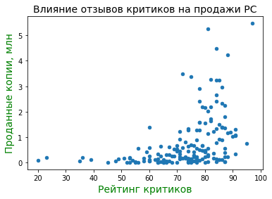

```python
print('Корелляция:', xone_ab['critic_score'].corr(xone_ab['all_sales']))

xone_ab.plot(x='critic_score', y='all_sales', kind='scatter')
plt.title('Влияние отзывов критиков на продажи PC', fontsize = 14)
plt.xlabel('Рейтинг критиков', color = 'green', fontsize = 14)
plt.ylabel('Проданные копии, млн', color = 'green', fontsize = 14);
```

##### 3DS 🎈

Добавляю появившуюся после правок платформу 3DS

```
Корелляция: 0.3494009303924131
```

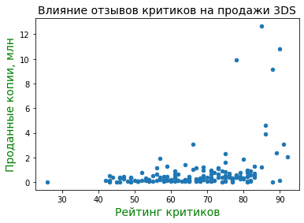

```python
print('Корелляция:', ds3['critic_score'].corr(ds3['all_sales']))

ds3.plot(x='critic_score', y='all_sales', kind='scatter')
plt.title('Влияние отзывов критиков на продажи 3DS', fontsize = 14)
plt.xlabel('Рейтинг критиков', color = 'green', fontsize = 14)
plt.ylabel('Проданные копии, млн', color = 'green', fontsize = 14);
```

#### Вывод

🎈 Полученные в ходе дополнительного исследования данные подтверждают уже имеющиеся.

#### Влияние отзывов пользователей на продажи

##### PS3

```
Корелляция: 0.12584269665485215
```

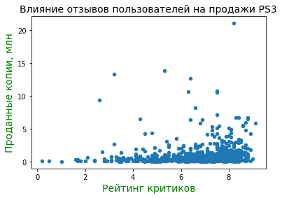

```python
print('Корелляция:', ps3['user_score'].corr(ps3['all_sales']))

ps3.plot(x='user_score', y='all_sales', kind='scatter')
plt.title('Влияние отзывов пользователей на продажи PS3', fontsize = 14)
plt.xlabel('Рейтинг критиков', color = 'green', fontsize = 14)
plt.ylabel('Проданные копии, млн', color = 'green', fontsize = 14);
```

###### АВ 🎈

```
Корелляция: 0.010779729319038044
```

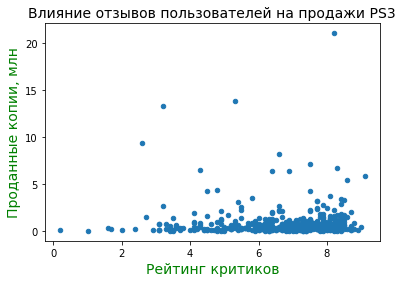

```python
print('Корелляция:', ps3_ab['user_score'].corr(ps3_ab['all_sales']))

ps3_ab.plot(x='user_score', y='all_sales', kind='scatter')
plt.title('Влияние отзывов пользователей на продажи PS3', fontsize = 14)
plt.xlabel('Рейтинг критиков', color = 'green', fontsize = 14)
plt.ylabel('Проданные копии, млн', color = 'green', fontsize = 14);
```

##### Wii

```
Корелляция: 0.11241436067003167
```

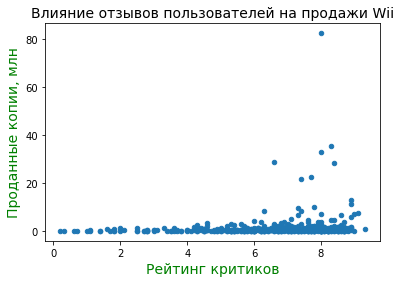

```python
print('Корелляция:', wii['user_score'].corr(wii['all_sales']))
wii.plot(x='user_score', y='all_sales', kind='scatter')
plt.title('Влияние отзывов пользователей на продажи Wii', fontsize = 14)
plt.xlabel('Рейтинг критиков', color = 'green', fontsize = 14)
plt.ylabel('Проданные копии, млн', color = 'green', fontsize = 14);
```

##### PS4

```
Корелляция: -0.031957110204556424
```

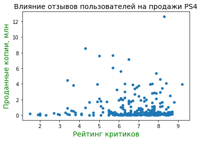

```python
print('Корелляция:', ps4['user_score'].corr(ps4['all_sales']))

ps4.plot(x='user_score', y='all_sales', kind='scatter')
plt.title('Влияние отзывов пользователей на продажи PS4', fontsize = 14)
plt.xlabel('Рейтинг критиков', color = 'green', fontsize = 14)
plt.ylabel('Проданные копии, млн', color = 'green', fontsize = 14);
```

###### АВ 🎈

```
Корелляция: -0.031957110204556424
```

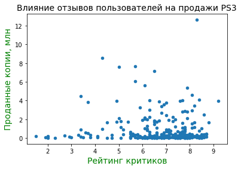

```python
print('Корелляция:', ps4_ab['user_score'].corr(ps4_ab['all_sales']))

ps4_ab.plot(x='user_score', y='all_sales', kind='scatter')
plt.title('Влияние отзывов пользователей на продажи PS3', fontsize = 14)
plt.xlabel('Рейтинг критиков', color = 'green', fontsize = 14)
plt.ylabel('Проданные копии, млн', color = 'green', fontsize = 14);
```

##### PC

print('Корелляция:', pc['user_score'].corr(pc['all_sales']))

pc.plot(x='user_score', y='all_sales', kind='scatter') plt.title('Влияние отзывов пользователей на продажи PC', fontsize = 14) plt.xlabel('Рейтинг критиков', color = 'green', fontsize = 14) plt.ylabel('Проданные копии, млн', color = 'green', fontsize = 14);

##### 3DS

```
Корелляция: 0.22480798039571082
```

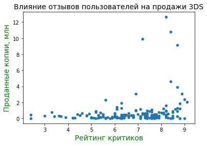

```python
print('Корелляция:', ds3['user_score'].corr(ds3['all_sales']))

ds3.plot(x='user_score', y='all_sales', kind='scatter')
plt.title('Влияние отзывов пользователей на продажи 3DS', fontsize = 14)
plt.xlabel('Рейтинг критиков', color = 'green', fontsize = 14)
plt.ylabel('Проданные копии, млн', color = 'green', fontsize = 14);
```

##### XOne

```
Корелляция: -0.06892505328279414
```

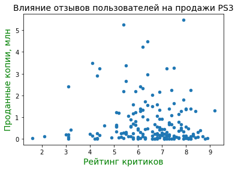

```python
print('Корелляция:', xone_ab['user_score'].corr(xone_ab['all_sales']))

xone_ab.plot(x='user_score', y='all_sales', kind='scatter')
plt.title('Влияние отзывов пользователей на продажи PS3', fontsize = 14)
plt.xlabel('Рейтинг критиков', color = 'green', fontsize = 14)
plt.ylabel('Проданные копии, млн', color = 'green', fontsize = 14);
```

#### Вывод

🎈Дополнительные исследования подтвердили имеющийся вывод.

### Оценка самых прибыльных жанров

Смотрю, какое количество игр в каком жанре выпущено за весь исследуемый период и отдельной таблицей начиная с 2006 года.

```python
df.pivot_table(index='genre', values ='name', aggfunc = 'count').sort_values(by='name', ascending = False)
```

| genre | name |
| --- | --- |
| Action | 3369 |
| Sports | 2347 |
| Misc | 1750 |
| Role-Playing | 1498 |
| Shooter | 1323 |
| Adventure | 1303 |
| Racing | 1247 |
| Platform | 887 |
| Simulation | 873 |
| Fighting | 849 |
| Strategy | 683 |
| Puzzle | 580 |

```python
df_actual.pivot_table(index='genre', values ='name', aggfunc = 'count').sort_values(by='name', ascending = False)
# выпуск игр начиная с 2006 года
```

| genre | name |
| --- | --- |
| Action | 1717 |
| Sports | 868 |
| Misc | 691 |
| Shooter | 642 |
| Role-Playing | 561 |
| Adventure | 438 |
| Racing | 402 |
| Simulation | 293 |
| Fighting | 247 |
| Strategy | 244 |
| Platform | 200 |
| Puzzle | 118 |

```python
df_alternative.pivot_table(index='genre', values ='name', aggfunc = 'count').sort_values(by='name', ascending = False)
# выпуск игр c 2011 года
```

| genre | name |
| --- | --- |
| Action | 1170 |
| Role-Playing | 397 |
| Sports | 371 |
| Shooter | 341 |
| Misc | 331 |
| Adventure | 295 |
| Racing | 186 |
| Fighting | 147 |
| Simulation | 132 |
| Platform | 112 |
| Strategy | 103 |
| Puzzle | 46 |

#### Вывод

🎈 За последние 5 лет игры в жанре Action не сдали свои позиции, Role-Playing поднялись на 2 место.  
Большая часть игр в жанре Action за 10-летний период вышла за последние 5 лет (1170 к 1717) то есть объем выпуска наращивается.  
Большая часть игр в жанре Role-Playing за 10-летний период вышла за последние 5 лет (397 к 561).

Меньше всего в жанрах Platform, Strategy и Puzzle, так же как и за последнее десятилетие.

Изучаю, какое количество копий было продано в каком жанре игры за весь исследуемый период.

#### Количство продаж по жанрам

```python
df.pivot_table(index = 'genre', values = 'all_sales', aggfunc = 'sum').sort_values(by='all_sales', ascending = False)
```

| genre | all_sales |
| --- | --- |
| Action | 1744.17 |
| Sports | 1331.26 |
| Shooter | 1052.45 |
| Role-Playing | 934.56 |
| Platform | 827.29 |
| Misc | 802.51 |
| Racing | 727.34 |
| Fighting | 447.53 |
| Simulation | 389.97 |
| Puzzle | 242.57 |
| Adventure | 237.59 |
| Strategy | 174.23 |

##### Вывод

Самые продаваемые игры за весь период исследования в жанре Action, самые маленькие продажи у игр в жанре Strategy.  
Интересное наблюдение, что игры в жанре Adventure занимают шестое место по количеству разработанных игр и предпоследнее по количеству проданных копий.

Смотрю, изменилось ли что-то со временем для актуальной выборки **и для альтернативной**.

```python
df_actual.pivot_table(index = 'genre', values = 'all_sales', aggfunc = 'sum').sort_values(by='all_sales', ascending = False)
```

| genre | all_sales |
| --- | --- |
| Action | 908.08 |
| Shooter | 686.99 |
| Sports | 663.77 |
| Misc | 399.33 |
| Role-Playing | 335.80 |
| Racing | 245.93 |
| Platform | 195.20 |
| Fighting | 142.18 |
| Simulation | 118.37 |
| Adventure | 76.86 |
| Strategy | 48.36 |
| Puzzle | 24.79 |

```python
(df_alternative.
 pivot_table(index = 'genre', values = 'all_sales', aggfunc = 'sum')
 .sort_values(by='all_sales', ascending = False))
```

| genre | all_sales |
| --- | --- |
| Action | 558.54 |
| Shooter | 408.48 |
| Sports | 237.03 |
| Role-Playing | 227.59 |
| Misc | 138.38 |
| Racing | 88.65 |
| Platform | 86.50 |
| Fighting | 64.37 |
| Simulation | 49.27 |
| Adventure | 40.15 |
| Strategy | 17.71 |
| Puzzle | 8.71 |

#### Вывод

Топ-3 игр не поменялся, но игры в жанре Shooter продаются больше, чем Sport, начиная с 2006 года. Для многих жанрах количество проданных копий растет с увеличением количества выпущенных игр в этом жанре.

Количество продаж игр в жанре Action в 37 раз больше продаж игр в жанре Puzzle. Разница в продажах между самыми популярными и самыми непопулярными играми огромная.

🎈 ТОП-3 игр не изменился в выборке за 5 лет по сравнению с 10-летней выборкой. Продажи игр в жанрах Action и Shooter увеличиваются (558.54 к 908.08 и 408.48 к 686.99), а продаж игр в жанре Sports стало меньше. Большая часть продаж игр в жанре Role-Playing пришлась на последние 5 лет из 10 (227.59 к 335.80).

Adventure, Strategy и Puzzle по-прежнему не популярны.

Создаю сводную таблицу Топ-5 жанров.

### Оценка количества продаж к количеству изданных игр 🎈

Выясняю, какое количество копий приходится на выпуск одной игры. Это позволит понять эффективность жанра.

```python
a = (df_actual
 .pivot_table(index = 'genre', values = ['all_sales','name'], aggfunc = {'all_sales':'sum','name':'count'}))
a['weighted_average'] = a['all_sales']/a['name']
a.sort_values(by='weighted_average', ascending = False).head()
```

| genre | all_sales | name | weighted_average |
| --- | --- | --- | --- |
| Shooter | 686.99 | 642 | 1.070078 |
| Platform | 195.20 | 200 | 0.976000 |
| Sports | 663.77 | 868 | 0.764712 |
| Racing | 245.93 | 402 | 0.611766 |
| Role-Playing | 335.80 | 561 | 0.598574 |

```python
b = (df_alternative
 .pivot_table(index = 'genre', values = ['all_sales','name'], aggfunc = {'all_sales':'sum','name':'count'}))

b['weighted_average'] = b['all_sales']/b['name']
b.sort_values(by='weighted_average', ascending = False).head()
```

| genre | all_sales | name | weighted_average |
| --- | --- | --- | --- |
| Shooter | 408.48 | 341 | 1.197889 |
| Platform | 86.50 | 112 | 0.772321 |
| Sports | 237.03 | 371 | 0.638895 |
| Role-Playing | 227.59 | 397 | 0.573275 |
| Action | 558.54 | 1170 | 0.477385 |

#### Вывод

Выгоднее всего производить игры в жанре Shooter, Platform, Sports и Role-Playing. Shooter и Platform держат первые два места на протяжении 10 лет.  
Action в последние 5 лет вытеснил жанр Racing из топ-5.

Беру топ-5 жанров за последние 5 лет. Так как в целом ничего не поменялось.

```python
top_5_genre = b.sort_values(by='weighted_average', ascending = False).head()
```

## Портрет пользователя по регионам

```python
df_actual.head() # вывожу начало таблицы, чтобы освежить память на названия столбцов и данные в них
```

|  | name | platform | year_of_release | genre | na_sales | eu_sales | jp_sales | other_sales | critic_score | user_score | rating | all_sales |
| --- | --- | --- | --- | --- | --- | --- | --- | --- | --- | --- | --- | --- |
| 0 | Wii Sports | Wii | 2006 | Sports | 41.36 | 28.96 | 3.77 | 8.45 | 76.0 | 8.0 | E | 82.54 |
| 1 | Mario Kart Wii | Wii | 2008 | Racing | 15.68 | 12.76 | 3.79 | 3.29 | 82.0 | 8.3 | E | 35.52 |
| 2 | Wii Sports Resort | Wii | 2009 | Sports | 15.61 | 10.93 | 3.28 | 2.95 | 80.0 | 8.0 | E | 32.77 |
| 3 | Wii Play | Wii | 2006 | Misc | 13.96 | 9.18 | 2.93 | 2.84 | 58.0 | 6.6 | E | 28.91 |
| 4 | New Super Mario Bros. Wii | Wii | 2009 | Platform | 14.44 | 6.94 | 4.70 | 2.24 | 87.0 | 8.4 | E | 28.32 |

### Портрет пользователя NA-региона

#### Топ-5 платформ

```python
top_5 #Вывожу топ-5 платформ по всем регионам за 10 лет
```

|  | platform | all_sales |
| --- | --- | --- |
| 0 | X360 | 963.17 |
| 1 | PS3 | 939.16 |
| 2 | Wii | 907.51 |
| 3 | PS4 | 314.14 |
| 4 | 3DS | 259.00 |

```python
(df_actual.pivot_table(index = 'platform', values = 'na_sales', aggfunc = 'sum')
 .sort_values(by='na_sales', ascending = False).head())  # Топ-5 платформ по NA за последние 10 лет
```

| platform | na_sales |
| --- | --- |
| X360 | 595.57 |
| Wii | 496.90 |
| PS3 | 393.49 |
| PS4 | 108.74 |
| XOne | 93.12 |

```python
top_5_ab #Вывожу топ-5 платформ по всем регионам за последние 5 лет
```

|  | platform | all_sales |
| --- | --- | --- |
| 0 | PS3 | 453.39 |
| 1 | X360 | 390.56 |
| 2 | PS4 | 314.14 |
| 3 | 3DS | 259.00 |
| 4 | XOne | 159.32 |

```python
(df_alternative.pivot_table(index = 'platform', values = 'na_sales', aggfunc = 'sum')
 .sort_values(by='na_sales', ascending = False).head())  # Топ-5 платформ по NA за последние 5 лет
```

| platform | na_sales |
| --- | --- |
| X360 | 233.53 |
| PS3 | 171.62 |
| PS4 | 108.74 |
| XOne | 93.12 |
| 3DS | 83.49 |

#### Вывод

🎈 За последние 5 лет Wii ушла из топ-5 списка любимых платформ Северной Америки, возможно, потому что в 2013 году поддержка Wii была прекращена. В топ-5 пробилась платформа 3DS. В целом предпочтения американцев совпадают с "общемировыми".

#### Топ-5 жанров

```python
top_5_genre #Топ-5 жанров для всех регионов
```

| genre | all_sales | name | weighted_average |
| --- | --- | --- | --- |
| Shooter | 408.48 | 341 | 1.197889 |
| Platform | 86.50 | 112 | 0.772321 |
| Sports | 237.03 | 371 | 0.638895 |
| Role-Playing | 227.59 | 397 | 0.573275 |
| Action | 558.54 | 1170 | 0.477385 |

```python
na_top_5 = df_actual.pivot_table(index = 'genre', values = 'na_sales', aggfunc = 'sum').sort_values(by='na_sales', ascending = False).head()
# na_top_5['sales_share'] = na_top_5['na_sales']/top_5_genre['all_sales'] не имеет смысла, т.к. топ 5 жанров расчитан за 5 лет
na_top_5 # Топ-5 жанров по NA и доля от всех продаж Топ-5 игр
```

| genre | na_sales |
| --- | --- |
| Action | 424.83 |
| Shooter | 355.12 |
| Sports | 339.55 |
| Misc | 222.51 |
| Role-Playing | 138.86 |

```python
na_top_5_ab = (df_alternative
               .pivot_table(index = 'genre', values = 'na_sales', aggfunc = 'sum')
               .sort_values(by='na_sales', ascending = False).head())
na_top_5_ab['sales_share'] = na_top_5_ab['na_sales']/top_5_genre['all_sales']
na_top_5_ab # Топ-5 жанров по NA и доля от всех продаж Топ-5 игр
```

| genre | na_sales | sales_share |
| --- | --- | --- |
| Action | 233.92 | 0.418806 |
| Shooter | 197.13 | 0.482594 |
| Sports | 110.63 | 0.466734 |
| Role-Playing | 80.28 | 0.352740 |
| Misc | 71.42 | NaN |

##### Вывод

Предпочтения Северной Америки за 10 и за 5 лет не изменились, жанр Misc стал менее популярен, а Role-Playing чуть более популярен.

Почти половина всех продаж приходится на Северную Америку. Североамериканский пользователь предпочитает жанр Action, в то время как в мире этот жанр занимает последнюю пятую строчку топа. Игры в жанре Platform не вошли в предпочтения пользователей этого региона.

#### Влияние рейтинга ESRB на продажи в регионе

```python
df_actual['rating'] = df_actual['rating'].fillna('Нет рейтинга')
df_actual.tail()
```

|  | name | platform | year_of_release | genre | na_sales | eu_sales | jp_sales | other_sales | critic_score | user_score | rating | all_sales |
| --- | --- | --- | --- | --- | --- | --- | --- | --- | --- | --- | --- | --- |
| 6416 | Aiyoku no Eustia | PSV | 2014 | Misc | 0.0 | 0.00 | 0.01 | 0.0 | NaN | NaN | Нет рейтинга | 0.01 |
| 6417 | Samurai Warriors: Sanada Maru | PS3 | 2016 | Action | 0.0 | 0.00 | 0.01 | 0.0 | NaN | NaN | Нет рейтинга | 0.01 |
| 6418 | LMA Manager 2007 | X360 | 2006 | Sports | 0.0 | 0.01 | 0.00 | 0.0 | NaN | NaN | Нет рейтинга | 0.01 |
| 6419 | Haitaka no Psychedelica | PSV | 2016 | Adventure | 0.0 | 0.00 | 0.01 | 0.0 | NaN | NaN | Нет рейтинга | 0.01 |
| 6420 | Winning Post 8 2016 | PSV | 2016 | Simulation | 0.0 | 0.00 | 0.01 | 0.0 | NaN | NaN | Нет рейтинга | 0.01 |

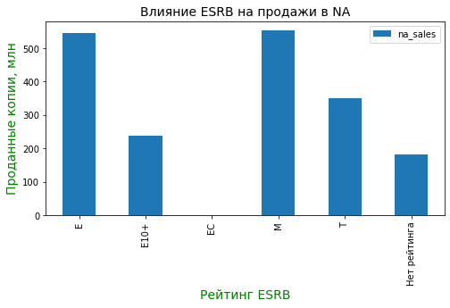

```python
(df_actual.pivot_table(index = 'rating', values = 'na_sales', aggfunc = 'sum')
.plot(kind = 'bar', figsize = (8,4)))
plt.title('Влияние ESRB на продажи в NA', fontsize = 14)
plt.xlabel('Рейтинг ESRB', color = 'green', fontsize = 14)
plt.ylabel('Проданные копии, млн', color = 'green', fontsize = 14);
```

Меньше всего продаж игр с рейтингом EC (Для детей младшего возраста).  
Больше всего продаж с рейтингом М (Для взрослых), Е (Для всех) и T (для подростков от 13 лет).  
🎈 Игры с отсутствующим рейтингом так же составляют большой объем продаж.

```python
df_alternative['rating'] = df_alternative['rating'].fillna('Нет рейтинга')
df_alternative.head()
```

|  | name | platform | year_of_release | genre | na_sales | eu_sales | jp_sales | other_sales | critic_score | user_score | rating | all_sales |
| --- | --- | --- | --- | --- | --- | --- | --- | --- | --- | --- | --- | --- |
| 0 | Grand Theft Auto V | PS3 | 2013 | Action | 7.02 | 9.09 | 0.98 | 3.96 | 97.0 | 8.2 | M | 21.05 |
| 1 | Grand Theft Auto V | X360 | 2013 | Action | 9.66 | 5.14 | 0.06 | 1.41 | 97.0 | 8.1 | M | 16.27 |
| 2 | Call of Duty: Modern Warfare 3 | X360 | 2011 | Shooter | 9.04 | 4.24 | 0.13 | 1.32 | 88.0 | 3.4 | M | 14.73 |
| 3 | Call of Duty: Black Ops 3 | PS4 | 2015 | Shooter | 6.03 | 5.86 | 0.36 | 2.38 | NaN | NaN | Нет рейтинга | 14.63 |
| 4 | Pokemon X/Pokemon Y | 3DS | 2013 | Role-Playing | 5.28 | 4.19 | 4.35 | 0.78 | NaN | NaN | Нет рейтинга | 14.60 |

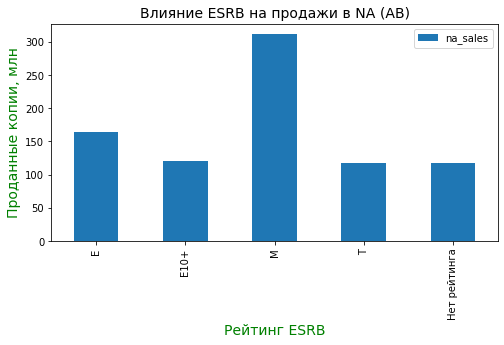

```python
(df_alternative.pivot_table(index = 'rating', values = 'na_sales', aggfunc = 'sum')
.plot(kind = 'bar', figsize = (8,4)))
plt.title('Влияние ESRB на продажи в NA (АВ)', fontsize = 14)
plt.xlabel('Рейтинг ESRB', color = 'green', fontsize = 14)
plt.ylabel('Проданные копии, млн', color = 'green', fontsize = 14);
```

🎈 За последнгие 5 лет игры с рейтингом EC (Для детей младшего возраста) вообще перестали продаваться или такой рейтинг перестал присваиваться.  
Больше всего продаж с рейтингом М (Для взрослых) и Е (Для всех). Доля продаж остальных игр сопоставима с продажами игр без рейтинга.

```python
df_alternative.query('rating =="Нет рейтинга"').tail(15)
```

|  | name | platform | year_of_release | genre | na_sales | eu_sales | jp_sales | other_sales | critic_score | user_score | rating | all_sales |
| --- | --- | --- | --- | --- | --- | --- | --- | --- | --- | --- | --- | --- |
| 3610 | Prison Architect | XOne | 2016 | Action | 0.01 | 0.00 | 0.00 | 0.0 | 74.0 | 6.7 | Нет рейтинга | 0.01 |
| 3611 | Hakuoki: Reimeiroku - Omouhase Kara | PSV | 2015 | Action | 0.00 | 0.00 | 0.01 | 0.0 | NaN | NaN | Нет рейтинга | 0.01 |
| 3612 | Hanasaku Manimani | PSV | 2014 | Adventure | 0.00 | 0.00 | 0.01 | 0.0 | NaN | NaN | Нет рейтинга | 0.01 |
| 3613 | Fujiko F. Fujio Characters: Great Assembly! Sl... | 3DS | 2014 | Action | 0.00 | 0.00 | 0.01 | 0.0 | NaN | NaN | Нет рейтинга | 0.01 |
| 3615 | Tsukigime Ranko's Longest Day | PS3 | 2014 | Action | 0.00 | 0.01 | 0.00 | 0.0 | NaN | NaN | Нет рейтинга | 0.01 |
| 3616 | Aikatsu Stars! My Special Appeal | 3DS | 2016 | Action | 0.00 | 0.00 | 0.01 | 0.0 | NaN | NaN | Нет рейтинга | 0.01 |
| 3618 | Kyoukai no Shirayuki | PSV | 2016 | Action | 0.00 | 0.00 | 0.01 | 0.0 | NaN | NaN | Нет рейтинга | 0.01 |
| 3619 | 7'scarlet | PSV | 2016 | Adventure | 0.00 | 0.00 | 0.01 | 0.0 | NaN | NaN | Нет рейтинга | 0.01 |
| 3621 | Dynasty Warriors: Eiketsuden | PS3 | 2016 | Action | 0.00 | 0.00 | 0.01 | 0.0 | NaN | NaN | Нет рейтинга | 0.01 |
| 3624 | The Longest 5 Minutes | PSV | 2016 | Action | 0.00 | 0.00 | 0.01 | 0.0 | NaN | NaN | Нет рейтинга | 0.01 |
| 3626 | Strawberry Nauts | PSV | 2016 | Adventure | 0.00 | 0.00 | 0.01 | 0.0 | NaN | NaN | Нет рейтинга | 0.01 |
| 3627 | Aiyoku no Eustia | PSV | 2014 | Misc | 0.00 | 0.00 | 0.01 | 0.0 | NaN | NaN | Нет рейтинга | 0.01 |
| 3628 | Samurai Warriors: Sanada Maru | PS3 | 2016 | Action | 0.00 | 0.00 | 0.01 | 0.0 | NaN | NaN | Нет рейтинга | 0.01 |
| 3629 | Haitaka no Psychedelica | PSV | 2016 | Adventure | 0.00 | 0.00 | 0.01 | 0.0 | NaN | NaN | Нет рейтинга | 0.01 |
| 3630 | Winning Post 8 2016 | PSV | 2016 | Simulation | 0.00 | 0.00 | 0.01 | 0.0 | NaN | NaN | Нет рейтинга | 0.01 |

```python
df_alternative.query('rating =="EC"') # за 5 лет не было продано ни одной игры с рейтингом EC
```

|  | name | platform | year_of_release | genre | na_sales | eu_sales | jp_sales | other_sales | critic_score | user_score | rating | all_sales |
| --- | --- | --- | --- | --- | --- | --- | --- | --- | --- | --- | --- | --- |

#### Возможные причины отсутствия рейтинга 🎈

- Сайт, с которого брали данные о рейтинге, не хранил данные о рейтингах для этих игр. т.к. отсутствуют рейтинги критиков и пользователей.
- Очень маленькие продажи, поэтому информацию о рейтингах не собирали для некоторых игр.
- Получение рейтинга ESRB - дело добровольное, он присваивается только по заявке создателя игры и предназначен для рынка [США, Канады и Мексики](https://okdk.ru/chto-oznachajut-rejtingi-videoigr-rukovodstvo-po-esrb-i-pegi/). Эти игры, возможно, изначально не предполагалось продавать там.

#### Портрет пользователя из NA-региона. Вывод 🎈

За 10-летний период: Взрослый или подросток, предпочитает игры в жанре Action, Shooter и Sport. Предпочитает приставки X360, Wii и PS3.

За 5-летний период: Взрослый или "человек без возраста", предпочитает игры в жанре Action, Shooter и Sport. Предпочитает приставки X360, PS3 и PS4.

Поднятие в рейтинге PS3 скорее всего связано не с тем, что у них лучше пошли продажи, а с тем, что Wii перестала продаваться.

### Портрет пользователя EU-региона

#### Топ-5 платформ

```python
top_5 #Вывожу топ-5 платформ по всем регионам за 10 лет
```

|  | platform | all_sales |
| --- | --- | --- |
| 0 | X360 | 963.17 |
| 1 | PS3 | 939.16 |
| 2 | Wii | 907.51 |
| 3 | PS4 | 314.14 |
| 4 | 3DS | 259.00 |

```python
(df_actual.pivot_table(index = 'platform', values = 'eu_sales', aggfunc = 'sum')
 .sort_values(by='eu_sales', ascending = False).head()) # Топ-5 платформ по Европе за 10 лет
```

| platform | eu_sales |
| --- | --- |
| PS3 | 329.80 |
| X360 | 270.33 |
| Wii | 262.21 |
| PS4 | 141.09 |
| PC | 102.33 |

```python
top_5_ab #Вывожу топ-5 платформ по всем регионам за 5 лет
```

|  | platform | all_sales |
| --- | --- | --- |
| 0 | PS3 | 453.39 |
| 1 | X360 | 390.56 |
| 2 | PS4 | 314.14 |
| 3 | 3DS | 259.00 |
| 4 | XOne | 159.32 |

```python
(df_alternative.pivot_table(index = 'platform', values = 'eu_sales', aggfunc = 'sum')
 .sort_values(by='eu_sales', ascending = False).head()) # Топ-5 платформ по Европе за 5 лет
```

| platform | eu_sales |
| --- | --- |
| PS3 | 165.69 |
| PS4 | 141.09 |
| X360 | 119.54 |
| 3DS | 61.48 |
| PC | 58.71 |

Наиболее популярная платформа в Европе - PS3 на протяжении 10 лет. Треть всех игр для этой платформы покупается пользователями в Европе. За ней идет PS4 и X360.  
Так же в Топ-5 попали игры для PC.

В Топ-5 не попала популярная платформа XOne.

#### Топ-5 жанров

```python
top_5_genre #Топ-5 жанров для всех регионов
```

| genre | all_sales | name | weighted_average |
| --- | --- | --- | --- |
| Shooter | 408.48 | 341 | 1.197889 |
| Platform | 86.50 | 112 | 0.772321 |
| Sports | 237.03 | 371 | 0.638895 |
| Role-Playing | 227.59 | 397 | 0.573275 |
| Action | 558.54 | 1170 | 0.477385 |

```python
eu_top_5 = (df_actual.pivot_table(index = 'genre', values = 'eu_sales', aggfunc = 'sum')
            .sort_values(by='eu_sales', ascending = False).head())

##eu_top_5['sales_share'] = eu_top_5['eu_sales']/top_5_genre['all_sales']
eu_top_5 #Топ-5 жанров для EU и для продаж от всех продаж Топ-5 игр
```

| genre | eu_sales |
| --- | --- |
| Action | 306.01 |
| Shooter | 234.19 |
| Sports | 222.98 |
| Misc | 112.81 |
| Racing | 100.34 |

```python
eu_top_5_ab = (df_alternative.pivot_table(index = 'genre', values = 'eu_sales', aggfunc = 'sum')
            .sort_values(by='eu_sales', ascending = False).head())

eu_top_5_ab['sales_share'] = eu_top_5_ab['eu_sales']/top_5_genre['all_sales']
eu_top_5_ab #Топ-5 жанров для EU и для продаж от всех продаж Топ-5 игр
```

| genre | eu_sales | sales_share |
| --- | --- | --- |
| Action | 201.22 | 0.360261 |
| Shooter | 150.18 | 0.367656 |
| Sports | 88.54 | 0.373539 |
| Role-Playing | 60.53 | 0.265961 |
| Racing | 41.14 | NaN |

Топ-3 популярных жанров в Европе: Action, Shooter и Sport, это соответствует "общемировым" предпочтениям.  
Так же пользователи из Европы предпочитают жанр Racing, который не попал в Топ-5 жанров по всем регионам и не так популярен в Северной Америке.

За последние 5 лет из топ-5 выпали игры в жанре Misc и появились Role-Playing, в остальном наблюдается стабильность.  
За 5 лет из 10 было куплено 2/3 игр в жанре Action, и 60% игр а жанре Shooter, т.е. продажи растут.

#### Влияние рейтинга ESRB на продажи в регионе

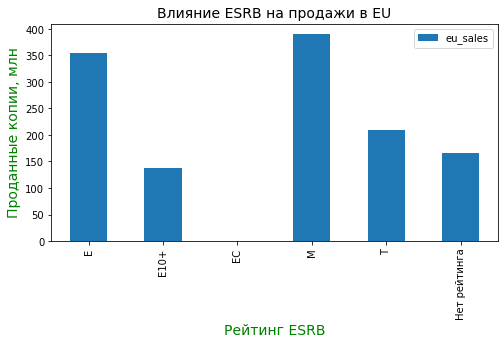

```python
(df_actual.pivot_table(index = 'rating', values = 'eu_sales', aggfunc = 'sum')
 .plot(kind = 'bar', figsize = (8,4)))
plt.title('Влияние ESRB на продажи в EU', fontsize = 14)
plt.xlabel('Рейтинг ESRB', color = 'green', fontsize = 14)
plt.ylabel('Проданные копии, млн', color = 'green', fontsize = 14);
```

Больше всего продаж на срезе в 10 лет в Европе приходится на игры с рейтингом М (Для взрослых), Е (Для всех) и Т(Подросткам от 13 лет).

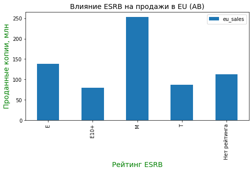

```python
(df_alternative.pivot_table(index = 'rating', values = 'eu_sales', aggfunc = 'sum')
 .plot(kind = 'bar', figsize = (8,4)))
plt.title('Влияние ESRB на продажи в EU (АВ)', fontsize = 14)
plt.xlabel('Рейтинг ESRB', color = 'green', fontsize = 14)
plt.ylabel('Проданные копии, млн', color = 'green', fontsize = 14);
```

На срезе в 5 лет пользователи из Европы так же предпочитают покупать игры с рейтингом М ("Для взрослых") и Е (Для всех). Выросла доля игр, для которых рейтинг не определен и ее продажи даже больше, чем у игр для подростков.

#### Портрет пользователя из Европы. Вывод

На срезе в 10 лет: Взрослый или подросток, в основном предпочитает играть на приставках Ps3, X360 и Wii, но так же не против использовать копьютер. Любимые жанры совпадают с "общемировыми" предпочтениями: Action, Shooter, Sport.

На срезе в 5 лет: Взрослый или "человек неопределенного возрата", предпочитает играть на приставках PS3, PS4 и X360, так же использует компьютер для игр и предпочитает жанры: Action, Shooter, Sport. Новое увлечение - игры в жанре Role-Playing.

### Портрет пользователя JP-региона

#### Топ-5 платформ

```python
top_5 #Вывожу топ-5 платформ по всем регионам
```

|  | platform | all_sales |
| --- | --- | --- |
| 0 | X360 | 963.17 |
| 1 | PS3 | 939.16 |
| 2 | Wii | 907.51 |
| 3 | PS4 | 314.14 |
| 4 | 3DS | 259.00 |

```python
(df_actual.pivot_table(index = 'platform', values = 'jp_sales', aggfunc = 'sum')
 .sort_values(by='jp_sales', ascending = False).head()) # Топ-5 платформ в Японии
```

| platform | jp_sales |
| --- | --- |
| 3DS | 100.67 |
| PS3 | 80.19 |
| Wii | 69.33 |
| PSV | 21.91 |
| PS4 | 15.96 |

```python
top_5_ab
```

|  | platform | all_sales |
| --- | --- | --- |
| 0 | PS3 | 453.39 |
| 1 | X360 | 390.56 |
| 2 | PS4 | 314.14 |
| 3 | 3DS | 259.00 |
| 4 | XOne | 159.32 |

```python
(df_alternative.pivot_table(index = 'platform', values = 'jp_sales', aggfunc = 'sum')
 .sort_values(by='jp_sales', ascending = False).head())
```

| platform | jp_sales |
| --- | --- |
| 3DS | 100.67 |
| PS3 | 50.17 |
| PSV | 21.91 |
| PS4 | 15.96 |
| WiiU | 13.01 |

🎈 На срезе в 5 лет пользователи из Японии по прежнему предпочитают свою консоль 3DS. Так же как и в других регионах по той же причине из рейтинга ушла Wii и появилась WiiU следующего поколения.  
Все еще популярна PSV.

3DS, PSV и WiiU судя по картинкам в интернете - портативные консоли, значит, для пользователей из Японии важен размер и возможность переноски устройства.

#### Топ-5 жанров

```python
top_5_genre #Топ-5 жанров для всех регионов
```

| genre | all_sales | name | weighted_average |
| --- | --- | --- | --- |
| Shooter | 408.48 | 341 | 1.197889 |
| Platform | 86.50 | 112 | 0.772321 |
| Sports | 237.03 | 371 | 0.638895 |
| Role-Playing | 227.59 | 397 | 0.573275 |
| Action | 558.54 | 1170 | 0.477385 |

```python
jp_top_5 = (df_actual.pivot_table(index = 'genre', values = 'jp_sales', aggfunc = 'sum')
            .sort_values(by='jp_sales', ascending = False).head())

##jp_top_5['sales_share'] = jp_top_5['jp_sales']/top_5_genre['all_sales']
jp_top_5 # Топ-5 жанров для Японии и доля продаж от всех продаж Топ-5 игр за 10 лет
```

| genre | jp_sales |
| --- | --- |
| Role-Playing | 79.38 |
| Action | 73.87 |
| Sports | 31.17 |
| Misc | 27.04 |
| Platform | 22.58 |

На срезе в 10 лет: Наиболее популярный жанр в Японии - Role-Playing. В Японии не популярны игры в жанре Shooter.

```python
jp_top_5_ab = (df_alternative.pivot_table(index = 'genre', values = 'jp_sales', aggfunc = 'sum')
            .sort_values(by='jp_sales', ascending = False).head())

jp_top_5_ab['sales_share'] = jp_top_5_ab['jp_sales']/top_5_genre['all_sales']
jp_top_5_ab # Топ-5 жанров для Японии и доля продаж от всех продаж Топ-5 игр для 5 лет
```

| genre | jp_sales | sales_share |
| --- | --- | --- |
| Role-Playing | 67.60 | 0.297025 |
| Action | 58.70 | 0.105095 |
| Misc | 15.65 | NaN |
| Shooter | 12.00 | 0.029377 |
| Platform | 11.72 | 0.135491 |

На срезе в 5 лет: Наиболее популярный жанр в Японии - Role-Playing, однако вклад Японии в покупку игр не превышает 30% в жанре Role-Playing от всех продаж в этом жанре.  
Становится популярным жанр Shooter и уходят из топ-5 игры в жанре Sports.

#### Влияние рейтинга ESRB на продажи в регионе

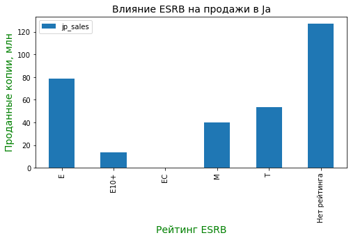

```python
(df_actual.pivot_table(index = 'rating', values = 'jp_sales', aggfunc = 'sum')
.plot(kind = 'bar', figsize = (8,4)))
plt.title('Влияние ESRB на продажи в Ja', fontsize = 14)
plt.xlabel('Рейтинг ESRB', color = 'green', fontsize = 14)
plt.ylabel('Проданные копии, млн', color = 'green', fontsize = 14);
```

🎈 На срезе в 10 лет: Больше всего продаж в Японии приходится на игры, для которых нет рейтинга ESRB, далее идут игры с рейтингом Е (Для всех), Т(Подросткам от 13 лет) и М (Для взрослых). Я думаю, что в Японии так популярны игры без рейтинга потому что, это игры, выпущенные в Японии для Японии, соответственно им не нужно было получать рейтинг ESRB.

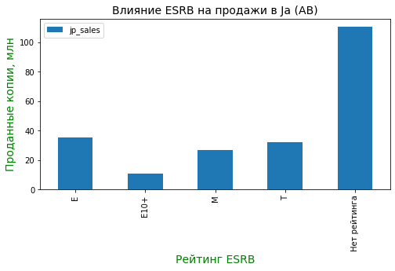

```python
(df_alternative.pivot_table(index = 'rating', values = 'jp_sales', aggfunc = 'sum')
.plot(kind = 'bar', figsize = (8,4)))
plt.title('Влияние ESRB на продажи в Ja (АВ)', fontsize = 14)
plt.xlabel('Рейтинг ESRB', color = 'green', fontsize = 14)
plt.ylabel('Проданные копии, млн', color = 'green', fontsize = 14);
```

🎈 На срезе в 5 лет: Игры без рейтинга - самые популярные в Японии, предполагаю, что специфичный японский рынок замкнулся на игры собственного производства, а игры, выпущенные для Америки стали менее популярны. Возможно, потому что своих игр стало больше, а вкусы сильно отличаются от европейских и американских.

#### Портрет пользователя из Ja-региона. Вывод

Портрет пользователя из Ja-региона  
Срез в 10 лет: У пользователя из Японии нет четкого возрастного идентификатора, это может быть как ребенок, так и взрослый. Пользователь предпочитает игры в жанре Role-Playing, Action и Sport. Предпочитает приставки 3DS, PS3 и Wii.

Срез в 5 лет: Пользователь неопределенного возраста. Возраст не играет значения. Пользователь предпочитает игры в жанре Role-Playing, Action и Misc . Предпочитает приставки 3DS, PS3 и PSV. Для пользователя из Японии является важной преимуществом при выборе консоли - ее портативность.

### Вывод о портрете пользователя из разных регионов

Пользователи из Северной Америки и Европы ближе друг к другу по предпочтениям как в выборе платформ, так и в выборе жанров игр. Пользователи из Северной Америки предпочитают играть исключительно на приставках. Пользователи из Европы так же используют для игры компьютеры. Самые любимы жанры это: Action, Shooter и Sport. Пользователи Северной Америки и Европы больше всего покупают игры для взрослых и для всех возрастов, так же интересуются играми для детей от 13 лет.

Японский пользователь предпочитает играть на "родных" портативных игровых системах 3DS и других приставках. Японский пользователь делает выбор в пользу ролевых игр. "Стрелялки" попали в Топ-5 игр только в последние 5 лет, самые любимые жанры: Role-Playing, Action и Sport. Японские пользователи в первую очередь интересуются играми для всех возрастов и и для портативных приставок. За последние 5 лет японских пользвателей перестали интересовать игры в жанре Sports. Так же пользователи из этого региона предпочитают игры, выпущенные не для американского рынка.

Самый "играющий" регион - это Северная Америка.

## Проверка гипотез

### Проверка гипотезы "Средние пользовательские рейтинги платформ Xbox One и PC одинаковые"

Нулевая гипотеза: Средние пользовательские рейтинги платформ Xbox One и PC одинаковые.  
Альтернативная гипотеза: Средние пользовательские рейтинги платформ Xbox One и PC разные.  
Гипотеза является двусторонней, так как рейтинг может быть как больше, так и меньше. Проверить гипотезу можно с помощью t-теста для гипотезы о равенстве двух генеральных совокупностей.

Первая совокупность - это данные о рейтинге по платформе Xbox One.  
Вторая совокупность - это данные о рейтинге по платформе PC.

Так как в столбце user_score есть пропущенные значения, то это может помешать проверке гипотезы. Удаляю все пропущенные значения из этого столбца.

```python
df_actual = df_actual.dropna(subset = ['user_score'])
df_alternative = df_alternative.dropna(subset = ['user_score'])
```

Создаю две выборки для проверки.

```python
xboxone_user_score  = df_actual.query('platform == "XOne"')['user_score']
pc_user_score = df_actual.query('platform == "PC"')['user_score']

xboxone_user_score_ab  = df_alternative.query('platform == "XOne"')['user_score'] # для альтернативного варианта в 5 лет
pc_user_score_ab = df_alternative.query('platform == "PC"')['user_score']
```

Проверяю равенство дисперсий.

```python
print(np.var(xboxone_user_score,ddof=1))
print(np.var(pc_user_score,ddof=1))
```

```
1.9069968429360702
2.30428209775906
```

```python
print(np.var(xboxone_user_score_ab, ddof=1)) # для альтернативного варианта в 5 лет
print(np.var(pc_user_score_ab,ddof=1))
```

```
1.9069968429360702
2.5666345404984403
```

Так как значения пользовательского рейтинга лежат между 0 и 10, то можно считать, что разница между дисперсиями достаточно большая, чтобы параметр equal_var был равен False. Alpha выбираю 1%, так как значения расположены очень близко и редкая игра получает оценки в большом диапазоне.

```python
results = st.ttest_ind(xboxone_user_score,pc_user_score, equal_var = False)
alpha = 0.01
print('p-значение: ', results.pvalue)

if results.pvalue < alpha:
    print("Отвергаем нулевую гипотезу")
else:
    print("Не получилось отвергнуть нулевую гипотезу")
```

```
p-значение:  0.010195606278101961
Не получилось отвергнуть нулевую гипотезу
```

```python
results = st.ttest_ind(xboxone_user_score_ab, pc_user_score_ab, equal_var = False)
alpha = 0.01
print('p-значение: ', results.pvalue)

if results.pvalue < alpha:
    print("Отвергаем нулевую гипотезу")
else:
    print("Не получилось отвергнуть нулевую гипотезу")
```

```
p-значение:  0.6821750204106906
Не получилось отвергнуть нулевую гипотезу
```

### Вывод

🎈На 5-летней выборке гипотезу о том, что средние пользовательские рейтинги платформ Xbox One и PC одинаковые, отвергнуть не получилось.

### Проверка гипотезы "Средние пользовательские рейтинги жанров Action и Sports разные"

Создаю две выборки для проверки.

```python
action_user_score  = df_actual.query('genre == "Action"')['user_score']
sports_user_score = df_actual.query('genre == "Sports"')['user_score']

action_user_score_ab  = df_alternative.query('genre == "Action"')['user_score']  # для альтернативного варианта в 5 лет
sports_user_score_ab = df_alternative.query('genre == "Sports"')['user_score']
```

Проверяю равенство дисперсий для определения, нужно ли будет использовать параметр equal_var.

```python
print(np.var(action_user_score,ddof=1))
print(np.var(sports_user_score,ddof=1))
```

```
1.7395719738593256
2.8631199467595567
```

```python
print(np.var(action_user_score_ab,ddof=1)) # для альтернативного варианта в 5 лет
print(np.var(sports_user_score_ab,ddof=1))
```

```
1.781999554246457
2.894071447078636
```

Разница между дисперсиями большая.  
Так же как и в проверке предыдущей гипотезы, устанавливаю параметр equal_var - False, и ставлю значение alpha - 1%.

```python
results = st.ttest_ind(action_user_score, sports_user_score, equal_var = False)
alpha = 0.01
print('p-значение: ', results.pvalue)

if results.pvalue < alpha:
    print("Отвергаем нулевую гипотезу")
else:
    print("Не получилось отвергнуть нулевую гипотезу")
```

```
p-значение:  4.780956913675287e-14
Отвергаем нулевую гипотезу
```

```python
results = st.ttest_ind(action_user_score_ab, sports_user_score_ab, equal_var = False)
alpha = 0.01
print('p-значение: ', results.pvalue)

if results.pvalue < alpha:
    print("Отвергаем нулевую гипотезу")
else:
    print("Не получилось отвергнуть нулевую гипотезу")
```

```
p-значение:  3.1604840664600617e-18
Отвергаем нулевую гипотезу
```

На пятилетней выборке гипотеза о том, что средние пользовательские рейтинги жанров Action и Sport равны, отвергнута, следовательно они не равны.

### Вывод

Средние пользовательские рейтинги жанров Action и Sports разные.

## Вывод

**Задача исследования: Вам нужно выявить определяющие успешность игры закономерности. Это позволит сделать ставку на потенциально популярный продукт и спланировать рекламные кампании.**

В ходе исследования выявленны закономерности: Самые успешные игры выпущены на английском языке для приставок PS3, X360 и PS4. Самый активный потребитель игр - это NA-регион и EU-регион. Самые популярные жанры в этих регионах: Action, Shooter, Sports.  
Игры в этих жанрах так же и выпускаются в большем количестве.

Самые успешные жанры:

- Shooter - на 1 игру в среднем приходится 1.1 миллион продаж.
- Platform - на 1 игру в среднем приходится 1 миллион продаж.
- Sport - на 1 игру в среднем приходится 0,7 миллионов продаж.

Для Ja-ругиона нужно учитывать региональную специфику, так как они предпочитают игры в жанрах Role-playing, Action и Misc. Пользователи Ja-региона предпочитают портативные консоли, но сам рынок небольшой. Так же регион специфический, здесь много продаж игр без рейтинга, которые, скорее всего являются локальными, созданными под азиатский рынок. Реклама должна создаваться точечно и только на Ja-регион.

Не следует тратить деньги на рекламу игр для приставок, которые уже вышли из употребления.

В последние 5 лет наблюдается три направления продаж по рейтингу ESRB:

- покупается много игр с рейтингом 18+.
- нейтральные игры, которые походят для всех возрастов.
- игры без рейтинга (возможно, не предназначенные для рынка США).

### Рекомендации

При ограниченном бюджете:  
Универсальным продуктом для всех регионов являются игры в жанре Action для приставок PS3.  
Наиболее привлекательный регион - NA, так как там самая большая аудитория.  
Так же следует провести дополнительное исследование конкурентов и удовлетворенности спроса в этом регионе.